# Justin Savoie

### Justin Savoie

English website

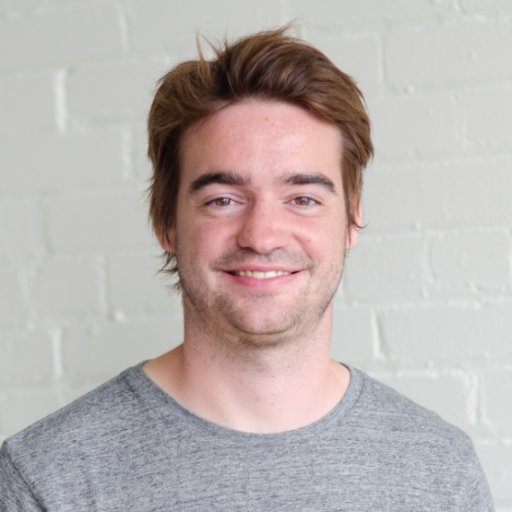

Je suis étudiant au doctorat en science politique à l’Université de Toronto. Auparavant, j’étais à l’Université Laval pour mon baccalauréat (économie et politique) et ma [maîtrise](https://corpus.ulaval.ca/jspui/bitstream/20.500.11794/33747/1/34864.pdf) (science politique).

Mes travaux portent sur le design et l’analyse de sondages, les méthodes computationelles en science sociale et l’analyse textuelle automatisée.

Ma thèse utilise les “word embeddings” et autres modèles d’espace vectoriel pour étudier l’évolution et les changements de signification en politique canadienne.

En plus de mes travaux universitaires, j’ai travaillé pendant quatre ans dans le secteur en science des données, d’abord en tant que scientifique des données, puis en tant que scientifique des données principal chez Vox Pop Labs, une entreprise sociale qui crée des applications web basées sur des enquêtes pour organiser les données socio-politiques. Dans le cadre de mon mandat, je dirige toutes les activités de science des données pour des projets tels que la [Boussole électorale](https://votecompass.com/), [Australia Talks](https://australiatalks.abc.net.au/) et le [COVID-19 Monitor](https://covid19monitor.org/). J’ai également de l’expérience en tant que consultant en analyse statistique de données d’enquête.

Mon profil [Google Scholar](https://scholar.google.ca/citations?user=U4l1gLYAAAAJ&hl=en).

#### Recherche

##### Articles évalués par les pairs

Dufresne, Y., Jérôme, B. Lewis-Beck, M. Murr, A.,Savoie, J. 2022. [Citizen Forecasting: The 2022 French Presidential Elections.](https://www.cambridge.org/core/journals/ps-political-science-and-politics/article/citizen-forecasting-the-2022-french-presidential-elections/0FBB7FDC3FAF7F41A2E99C595D7753AF) *PS: Political Science & Politics.*

Daoust, J-F., Nadeau, R., Dassonneville, R., Lachapelle, E., Bélanger, E. Savoie, J., van der Linden, C. 2020. How to Survey Citizens’ Compliance with COVID-19 Public Health Measures: Evidence from Three Survey Experiments *Journal of Experimental Political Science*

Donnelly, M., Islam, MMD., Savoie, J., 2020. [“The public face of interest group lobbying on immigration: who responds to and who ignores what they say”](https://journals.sagepub.com/doi/full/10.1177/0958928720954685?casa_token=dKtwmw91kUwAAAAA%3A7-2AVy2Z0zO-V9qYbOMykg2h9jbLjz1rDeKjP-qLETR7He_8EMrGnZ7mp7iMKtv2Vi_LLaATjBcBGhU) *European Journal of Social Policy*

van der Linden, C. Savoie, J., 2020. “Does collective interest or self-interest motivate mask usage as a preventive measure against COVID-19?” *Canadian Journal of Political Science*.

Savoie, J., van der Linden, C., Breton, C. 2020. [“Realignment and voter issue preferences in Quebec’s 2018 provincial election: A conjoint experiment](https://link.springer.com/article/10.1057%2Fs41253-020-00123-9) *French Politics*

Temporão, M., Dufresne, Y., Savoie, J., van der Linden, C. 2019. [Crowdsourcing the Vote: New Horizons in Citizen Forecasting](https://www.sciencedirect.com/science/article/pii/S0169207018301274?casa_token=MAm7ZaTrVGoAAAAA:XEAPypgHVVQ9j_rO-bfHPVpy2sSdW1uzUJroXQqpaVpBCsmaKtE5bVeKOfgRjQttZSr3wEA9oT4H) *International Journal of Forecasting*

Fréchet, N., Savoie, J., Dufresne, Y. 2019. [Analysis of Text-Analysis Syllabi: Building a Text-Analysis Syllabus Using Scaling](https://www.cambridge.org/core/journals/ps-political-science-and-politics/article/analysis-of-textanalysis-syllabi-building-a-textanalysis-syllabus-using-scaling/63FD1DC30AEDAF1D2DC10D4FEDA539A7) *PS: Political Science and Politics*.

##### Chapitres de livres

Elder, E., Lees-Marshment, J., Chant L., Osborne, D., Savoie, J., van der Linden, C. 2021 *What the Market Wanted: Vote Compass 2020 and Public Views on Issues and Leadership* in [Political Marketing and Management in the 2020 New Zealand General Election](https://link.springer.com/book/10.1007/978-3-030-77333-5). Palgrave Pivot

Elder, E., Lees-Marshment, J., Chant L., Osborne, D., Savoie, J., van der Linden, C. 2021 *Targeting Party Supporters, Key Demographics and Undecided Voters* in [Political Marketing and Management in the 2020 New Zealand General Election](https://link.springer.com/book/10.1007/978-3-030-77333-5). Palgrave Pivot

Lees-Marshment, J., Elder, E., Chant L., Osborne, D., Savoie, J., van der Linden, C. 2018. *Vote Compass NZ 2017: Marketing Insights into Public Views on Policy and Leaders* in [Political Marketing and Management in the 2017 New Zealand Election](https://www.palgrave.com/gp/book/9783319942971). Palgrave Pivot

Lees-Marshment, J., Elder, E., Chant L., Osborne, D., Savoie, J., van der Linden, C. 2018. *Political Parties and Their Customers: The Alignment of Party Policies with Supporter, Target and Undecided Market Preferences* in [Political Marketing and Management in the 2017 New Zealand Election](https://www.palgrave.com/gp/book/9783319942971). Palgrave Pivot

##### Soumis ou en R&R

Getting the Message: Why Mail-Delivered GOTV Interventions Succeed or Fail (avec Alexandre Fortier-Chouinard, Marc André Bodet, François Gélineau, Mathieu Ouimet)

Increasing Lobbying Transparency Through an Oversight in Designing a Health System Governance Reform (avec Mathieu Ouimet and Eric Montigny)

Where is the EU-UK Relationship Heading in the Medium-Term? A Conjoint Survey Experiment of Brexit Trade-Offs (avec Simon Hix, Clifton van der Linden, Joanna Massie, Mark Pickup)

#### Me contacter

[Twitter justinsavoie](https://twitter.com/justinsavoie)

[LinkedIn Justin Savoie](https://www.linkedin.com/in/justin-savoie-a7793932/)

[Github justinsavoie](https://github.com/justinsavoie)

Courriel: justin.savoie@mail.utoronto.ca